# Project 1: Wrangling, Exploration, Visualization

SDS322E

## Data Wrangling, Exploration, Visualization

### Connor Hixon, cjh4572

#### Introduction

Going back to my freshman year, I have begun to track analytics for The University of Texas basketball team. These two data sets each include information regarding every offensive play Texas basketball had in 2020-21 season. I recorded all of the data by watching each offensive play and tracking specific variables. For each play I recorded: Game #, Date, Opponent, Type of Game, Home/Away, Transition, Garbage Time Clutch Time, Possessions, Play ID, Number of Passes and more in dataset 1. For dataset 2 I recorded: Assist Opportunity, Shooter, Hockey Assist, Paint Touch, Cause of Paint Touch, Play Result and Point Result for each play in the 2020-21 season. The goal was to help UT basketball gain more knowledge into the numbers behind the game.

```r
library(tidyverse)
library(gt)
# read your datasets in here, e.g., with read_csv()
data1 <- read_csv("/stor/home/cjh4572/DATA/Dataset1.csv")
data2 <- read_csv("/stor/home/cjh4572/DATA/Dataset2.csv")
```

#### Tidying: Reshaping

If your datasets are tidy already, demonstrate that you can reshape data with pivot wider/longer here (e.g., untidy and then retidy). Alternatively, it may be easier to wait until the wrangling section so you can reshape your summary statistics. Note here if you are going to do this.

```r
# your tidying code (if applicable; can also wait until
# wrangling section) Waiting until the wrangling section to
# perform pivot wider/longer
```

In the Wrangling section I used pivot_wider to find the total number of points scored by each player based on the shot type the player took throughout the season. The shot type column I expanded so that each row became a column heading and I could see how many points each player scored according to the shot type.

#### Joining/Merging

```r
# your joining code
data <- full_join(data1, data2, by = c("GAME.#", "PLAY.ID", "POSS.#"))
```

Data 1 contains information regarding whether the game was at home, who the opponent was, was the play a transition play, did the play happen in garbage time or clutch time, or what date did the game happen. Data 2 contains more of the specifics of what happen in the play such as who shot the ball, who was the assist man, and what was the final outcome of the play. I performed a full_join to join the data by what game # in the season it was and what Possession number/Play ID the row was to make sure the data was in order of when the offensive plays happened. I performed a full join by these three variables because each dataset provides information about one offensive possession. Possession number and Play ID are different because one possession could consist of multiple play IDs due to offensive rebounds or dead ball plays.

In the data (joined datasets together) table, it contains 28 variables and 2374 observations. From data 1 there it contains 16 unique variables that were not found in data 2. These variables were: season, Date, Opponent, Conference/Non-Conference, Home/away, W/L, Half, Clutch?, Transition?, Garbage?, 2nd.Chance, Man or Zone, Assist Opportunity, Passes, Hockey Assist, Shooter. For data 2, there were 9 unique variables not found in data 1 and they were: Shot Clock Third, Shot Type, Contested, Paint Touch, Cause of Paint Touch, Paint Attacker, Defender Attacker, Play Result, Point Result.

#### Wrangling

```r
# Points by Shot Type using pivot_wider
points <- data %>% select(SHOOTER, SHOT.TYPE, POINT.RESULT, PLAY.RESULT) %>%
    filter(SHOOTER != "N/A") %>% group_by(SHOOTER, SHOT.TYPE) %>%
    summarize(sum = sum(POINT.RESULT)) %>% pivot_wider(names_from = "SHOT.TYPE",
    values_from = "sum") %>% select(-"N/A") %>% gt %>% tab_header("Total Points by Shot Type")
points
```

Total Points by Shot Type

| Catch-and-shoot | Dunk | Layup | Off-the-dribble (2) | Off-the-dribble (3) | Floater/Runner | Free Throws | Halfcourt Shot | Tip | Hook (Post) |
| --- | --- | --- | --- | --- | --- | --- | --- | --- | --- |
| 0 Gerald Liddell |  |  |  |  |  |  |  |  |  |
| 9 | 2 | 4 | 0 | 1 | NA | NA | NA | NA | NA |
| 1 Andrew Jones |  |  |  |  |  |  |  |  |  |
| 107 | 15 | 115 | 45 | 60 | 19 | 17 | 0 | 2 | NA |
| 10 Donovan Williams |  |  |  |  |  |  |  |  |  |
| 14 | 4 | 10 | 8 | 0 | 11 | 0 | NA | NA | 2 |
| 13 Jase Febres |  |  |  |  |  |  |  |  |  |
| 51 | NA | 2 | 2 | 6 | NA | 4 | 0 | NA | NA |
| 14 Drayton Whiteside |  |  |  |  |  |  |  |  |  |
| 0 | NA | NA | NA | NA | NA | NA | NA | NA | NA |
| 2 Matt Coleman III |  |  |  |  |  |  |  |  |  |
| 80 | 9 | 114 | 46 | 51 | 30 | 30 | 0 | NA | NA |
| 20 Jericho Sims |  |  |  |  |  |  |  |  |  |
| 0 | 133 | 82 | 2 | NA | 5 | 7 | NA | 2 | 12 |
| 22 Kai Jones |  |  |  |  |  |  |  |  |  |
| 40 | 111 | 49 | 8 | 3 | 2 | 12 | NA | 3 | 0 |
| 3 Courtney Ramey |  |  |  |  |  |  |  |  |  |
| 102 | 4 | 99 | 27 | 48 | 19 | 16 | NA | 2 | 1 |
| 30 Brock Cunningham |  |  |  |  |  |  |  |  |  |
| 27 | NA | 11 | NA | 0 | NA | 1 | NA | NA | 0 |
| 33 Kamaka Hepa |  |  |  |  |  |  |  |  |  |
| 27 | NA | NA | NA | NA | 0 | NA | NA | NA | NA |
| 34 Blake Nevins |  |  |  |  |  |  |  |  |  |
| NA | NA | 2 | NA | 0 | NA | NA | NA | NA | NA |
| 4 Greg Brown |  |  |  |  |  |  |  |  |  |
| 90 | 47 | 66 | 8 | 11 | 9 | 12 | NA | 0 | 0 |
| 5 Royce Hamm Jr. |  |  |  |  |  |  |  |  |  |
| 3 | 9 | 24 | NA | NA | NA | NA | NA | 4 | 2 |

```r
# Count of Shot Type attempts each player had
count <- data %>% select(SHOOTER, SHOT.TYPE, POINT.RESULT, PLAY.RESULT) %>%
    filter(SHOOTER != "N/A") %>% group_by(SHOOTER, SHOT.TYPE) %>%
    summarize(count = n()) %>% pivot_wider(names_from = "SHOT.TYPE",
    values_from = "count") %>% select(-`N/A`)
count[is.na(count)] <- 0
count
```

```
## # A tibble: 14 x 11
## # Groups:   SHOOTER [14]
##    SHOOTER `Catch-and-shoo…  Dunk Layup `Off-the-dribbl… `Off-the-dribbl…
##    <chr>              <int> <int> <int>            <int>            <int>
##  1 0 Gera…                8     2     5                1                2
##  2 1 Andr…              109    10   102               48               57
##  3 10 Don…               20     4    11                8                3
##  4 13 Jas…               49     0     1                1                5
##  5 14 Dra…                1     0     0                0                0
##  6 2 Matt…               62     6    79               43               52
##  7 20 Jer…                2    73    63                2                0
##  8 22 Kai…               36    65    39               13                6
##  9 3 Cour…               78     2    94               51               44
## 10 30 Bro…               36     0    10                0                1
## 11 33 Kam…               17     0     0                0                0
## 12 34 Bla…                0     0     1                0                1
## 13 4 Greg…               84    36    50               11               17
## 14 5 Royc…                3     5    25                0                0
## # … with 5 more variables: `Floater/Runner` <int>, `Free Throws` <int>,
## #   `Halfcourt Shot` <int>, Tip <int>, `Hook (Post)` <int>
```

```r
# Finishing at the rim, used for the graphs
at_rim <- data %>% select(SHOOTER, SHOT.TYPE, POINT.RESULT) %>%
    filter(SHOT.TYPE == "Layup" | SHOT.TYPE == "Dunk") %>% group_by(SHOOTER) %>%
    mutate(sum_points = sum(POINT.RESULT)) %>% summarize(count = n(),
    pp = sum_points/count) %>% summarize(PPP = mean(pp)) %>%
    arrange(desc(PPP))
at_rim
```

```
## # A tibble: 12 x 2
##    SHOOTER               PPP
##    <chr>               <dbl>
##  1 13 Jase Febres      2
##  2 34 Blake Nevins     2
##  3 20 Jericho Sims     1.58
##  4 22 Kai Jones        1.54
##  5 2 Matt Coleman III  1.45
##  6 4 Greg Brown        1.31
##  7 1 Andrew Jones      1.16
##  8 30 Brock Cunningham 1.1
##  9 5 Royce Hamm Jr.    1.1
## 10 3 Courtney Ramey    1.07
## 11 10 Donovan Williams 0.933
## 12 0 Gerald Liddell    0.857
```

```r
# PLAYS Summary Descriptive
data %>% group_by(`GAME.#`) %>% summarize(total_plays = n()) %>%
    summarize(mean = mean(total_plays), sd = sd(total_plays),
        min = min(total_plays), max = max(total_plays), total = sum(total_plays))
```

```
## # A tibble: 1 x 5
##    mean    sd   min   max total
##   <dbl> <dbl> <int> <int> <int>
## 1  87.9  8.84    75   121  2374
```

```r
# POSSESSIONS Summary Descriptive
data %>% group_by(`GAME.#`) %>% mutate(possessions = max(`POSS.#`),
    total_plays = n()) %>% summarize(total_poss = mean(possessions),
    total_plays = mean(total_plays)) %>% summarize(sum = sum(total_poss),
    min = min(total_poss), max = max(total_poss), median = median(total_poss),
    cor(total_poss, total_plays))
```

```
## # A tibble: 1 x 5
##     sum   min   max median `cor(total_poss, total_plays)`
##   <dbl> <dbl> <dbl>  <dbl>                          <dbl>
## 1  1911    60    93     70                          0.937
```

```r
# Points per Play for the season
data %>% group_by(`GAME.#`) %>% mutate(total = sum(POINT.RESULT)) %>%
    summarize(Points_Per_Play = total/n()) %>% summarize(PPP = mean(Points_Per_Play)) %>%
    summarize(mean_PPP = mean(PPP), min_PPP = min(PPP), max_PPP = max(PPP),
        sd_PPP = sd(PPP), quantile(PPP, 0.75))
```

```
## # A tibble: 1 x 5
##   mean_PPP min_PPP max_PPP sd_PPP `quantile(PPP, 0.75)`
##      <dbl>   <dbl>   <dbl>  <dbl>                 <dbl>
## 1    0.854   0.554    1.01  0.105                 0.922
```

```r
# Categorical counts
data %>% group_by(`CLUTCH?`) %>% summarize(n())
```

```
## # A tibble: 2 x 2
##   `CLUTCH?` `n()`
##   <lgl>     <int>
## 1 FALSE      2206
## 2 TRUE        168
```

```r
data %>% group_by(PAINT.TOUCH) %>% summarize(n())
```

```
## # A tibble: 2 x 2
##   PAINT.TOUCH `n()`
##   <lgl>       <int>
## 1 FALSE         999
## 2 TRUE         1375
```

```r
data %>% group_by(`TRANSITION?`) %>% summarize(n())
```

```
## # A tibble: 2 x 2
##   `TRANSITION?` `n()`
##   <lgl>         <int>
## 1 FALSE          2196
## 2 TRUE            178
```

```r
data %>% group_by(`GARBAGE?`) %>% summarize(n())
```

```
## # A tibble: 2 x 2
##   `GARBAGE?` `n()`
##   <lgl>      <int>
## 1 FALSE       2351
## 2 TRUE          23
```

```r
data %>% group_by(`2ND.CHANCE?`) %>% summarize(n())
```

```
## # A tibble: 2 x 2
##   `2ND.CHANCE?` `n()`
##   <lgl>         <int>
## 1 FALSE          2084
## 2 TRUE            290
```

```r
data %>% group_by(`CONTESTED?`) %>% summarize(n())
```

```
## # A tibble: 3 x 2
##   `CONTESTED?` `n()`
##   <chr>        <int>
## 1 FALSE          421
## 2 N/A            644
## 3 TRUE          1309
```

```r
data %>% group_by(`DEFENDER-ATTACKER`) %>% summarize(n())
```

```
## # A tibble: 3 x 2
##   `DEFENDER-ATTACKER` `n()`
##   <chr>               <int>
## 1 N/A                  1075
## 2 Opponent-Big          540
## 3 Opponent-Guard        759
```

```r
# Count number of NA in each column
data %>% summarize_all(function(x) sum(str_detect(x, "N/A")))
```

```
## # A tibble: 1 x 28
##   SEASON `GAME.#`  DATE OPPONENT `CONF/NON-CONF` `HOME/AWAY` `WIN/LOSS`  HALF
##    <int>    <int> <int>    <int>           <int>       <int>      <int> <int>
## 1      0        0     0        0               0           0          0    NA
## # … with 20 more variables: `POSS.#` <int>, PLAY.ID <int>, `CLUTCH?` <int>,
## #   `GARBAGE?` <int>, `TRANSITION?` <int>, `2ND.CHANCE?` <int>,
## #   `MAN.OR.ZONE?` <int>, PASSES <int>, ASSIST.OPPORTUNITY <int>,
## #   HOCKEY.ASSIST <int>, SHOOTER <int>, SHOT.CLOCK.THIRD <int>,
## #   SHOT.TYPE <int>, `CONTESTED?` <int>, PAINT.TOUCH <int>,
## #   CAUSE.OF.PAINT <int>, PAINT.ATTACKER <int>, `DEFENDER-ATTACKER` <int>,
## #   PLAY.RESULT <int>, POINT.RESULT <int>
```

When looking at the total plays this season, Texas basketball had 2374 total plays ran this season. We averaged 87.9 plays per game with a standard deviation of 8.84. The least plays we ran in a game was 75 and the most plays we ran in a game was 121. For points per play, Texas averaged 0.854 points per play (PPP) last season. Their best game, Texas had a 1.01 PPP and in their worst game they had a 0.55 PPP which is a pretty significant gap. Also, one interesting finding I found when counting up the categorical variables that Texas had 1,375 plays in the season with a paint touch and 999 plays in the season without a paint touch. This shows that in over 50% of Texas plays they were able to achieve a paint touch.

When looking at the total points per shot table, we can see which players produced the most points by what shot type it was. Andrew Jones found a lot of success last season off of Catch & Shoot shots producing 107 points, team high. Players such as Jericho Sims and Kai Jones found lot of their success in the point as Sims had 133 points on Dunks and Jones had 111 points. When looking at the counts of shot type for each player you are able to find more context about the total points. For an example, Andrew Jones has 60 points on off-the-dribble (3) while Courtney Ramey has 48. However, Jones has had 13 more attempts than Ramey making his efficiency lower.

#### Visualizing

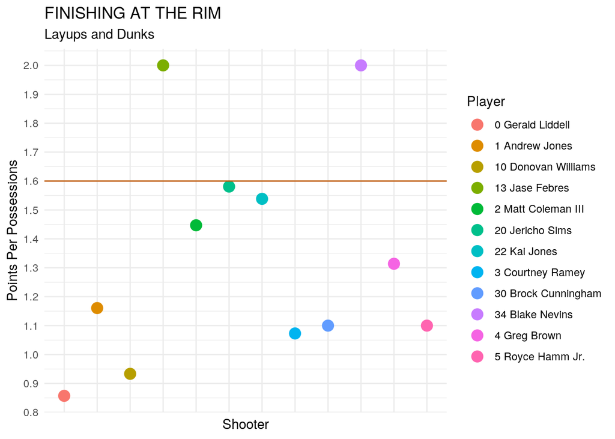

```r
at_rim %>% ggplot(aes(x = SHOOTER, y = PPP)) + geom_point(aes(color = SHOOTER),
    size = 4) + xlab("Shooter") + ylab("Points Per Possessions") +
    geom_hline(yintercept = 1.6, color = "#BF5700") + theme_minimal() +
    theme(axis.text.x = element_blank()) + labs(title = "FINISHING AT THE RIM",
    subtitle = "Layups and Dunks", color = "Player") + scale_y_continuous(breaks = seq(0.8,
    2, 0.1))
```

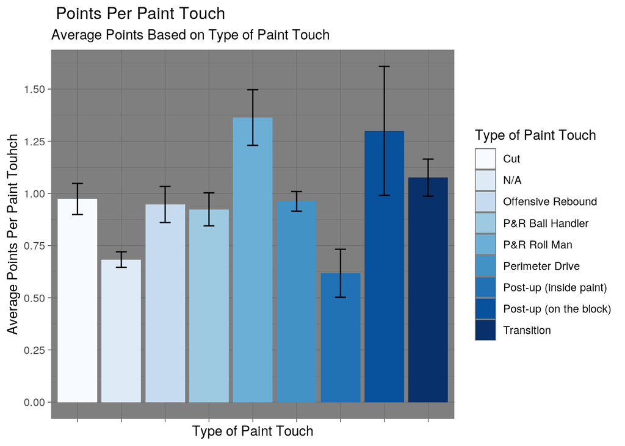

```r
data %>% select(CAUSE.OF.PAINT, POINT.RESULT) %>% na.omit() %>%
    ggplot(aes(x = CAUSE.OF.PAINT, y = POINT.RESULT, fill = CAUSE.OF.PAINT)) +
    geom_bar(stat = "summary") + geom_errorbar(stat = "summary",
    fun.data = mean_se, width = 0.25) + theme_dark() + theme(axis.text.x = element_blank()) +
    scale_fill_brewer() + labs(title = " Points Per Paint Touch",
    subtitle = "Average Points Based on Type of Paint Touch",
    x = "Type of Paint Touch", y = "Average Points Per Paint Touhch",
    fill = "Type of Paint Touch") + scale_y_continuous(breaks = seq(0,
    1.75, 0.25))
```

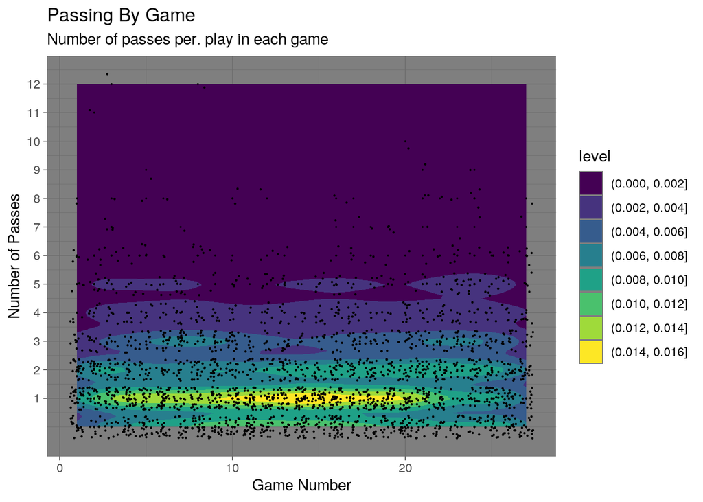

```r
data %>% select(`GAME.#`, PASSES) %>% ggplot(aes(x = `GAME.#`,
    y = PASSES)) + geom_density2d_filled() + geom_point(size = 0.01) +
    geom_jitter(size = 0.1) + scale_y_continuous(breaks = seq(1,
    12, 1)) + theme_dark() + labs(title = "Passing By Game",
    x = "Game Number", y = "Number of Passes", subtitle = "Number of passes per. play in each game")
```

The last graph shows number of passes for each possessions in each game. You can see that there was a high density on possessions with only 1 pass. Most possessions in the year fell between 0 and 4 passes total on the play. There was a very low density of possessions with more than 5 passes and you can see from the points that the most passes on one play was 12. Also towards the end of the season, Texas began to have more passes on their plays with 5 and 6 passes.

#### Concluding Remarks

In basketball there is so much analytics that makes up the game. However, when looking at specifics such as shot type by players, points per play, or number of passes this allows for the team to get a better understanding of why they succeed or failed. In the project, I was able to identify some of the analytics that made up Texas Basketball season last year that can be helpful when going into the new 2021-22 basketball season.